# "Visit with Us" Project

#### NumberOfPersonVisiting

```
ProdTaken                  0    1   All
NumberOfPersonVisiting
All                     3968  920  4888
3                       1942  460  2402
2                       1151  267  1418
4                        833  193  1026
1                         39    0    39
5                          3    0     3
------------------------------------------------------------------------------------------------------------------------
```

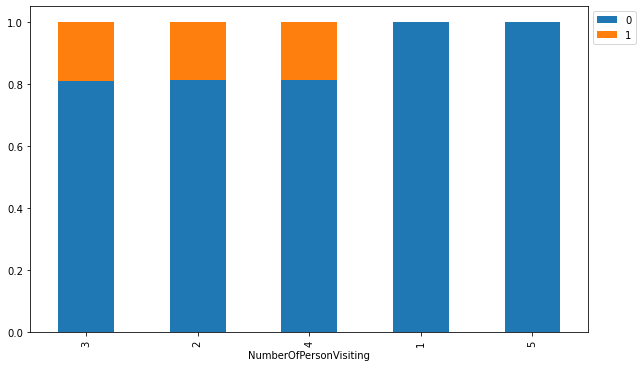

```python
stacked_barplot(df, "NumberOfPersonVisiting", 'ProdTaken')
```

##### Observation

- Customers who bought package looks like planned to travel in groups from 2 to 4 people

#### NumberOfFollowups

```
ProdTaken             0    1   All
NumberOfFollowups
All                3968  920  4888
4                  1689  379  2068
3                  1259  252  1511
5                   577  191   768
6                    82   54   136
2                   205   24   229
1                   156   20   176
------------------------------------------------------------------------------------------------------------------------
```

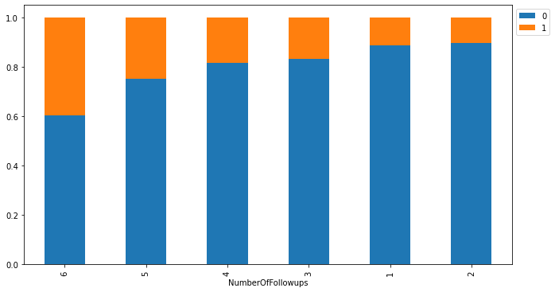

```python
stacked_barplot(df, "NumberOfFollowups", 'ProdTaken')
```

#### Observation

- The pattern here looks to be that more follow ups were related to greater sales though we cannot determine a causal link in that direction - meaning we cannot conclude that more follow ups resulted in more sales

#### NumberOfTrips

```
ProdTaken         0    1   All
NumberOfTrips
All            3968  920  4888
2              1165  299  1464
3               990  229  1219
1               508  112   620
6               258   64   322
5               396   62   458
7               156   62   218
4               417   61   478
8                76   29   105
19                0    1     1
20                0    1     1
21                1    0     1
22                1    0     1
------------------------------------------------------------------------------------------------------------------------
```

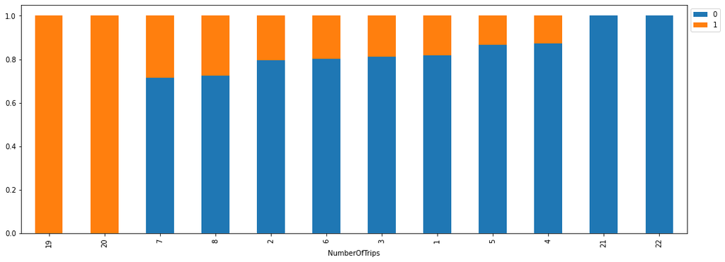

```python
stacked_barplot(df, "NumberOfTrips", 'ProdTaken')
```

##### Observation

- Outliers, those who reported average 19 trips/year or more, are muddling the story told by the graph above. If we focus on average trips/year reported between 1 and 8, we see that customers who reported greater number of average trips annually also tended to purchase travel package in greater proportion

#### NumberOfChildrenVisiting

```
ProdTaken                    0    1   All
NumberOfChildrenVisiting
All                       3968  920  4888
1                         1747  399  2146
2                         1082  253  1335
0                          880  202  1082
3                          259   66   325
------------------------------------------------------------------------------------------------------------------------
```

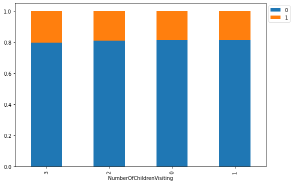

```python
stacked_barplot(df, "NumberOfChildrenVisiting", 'ProdTaken')
```

##### Observation

- Customers who purchased travel package did not differ much from those who did not make purchase in terms of number of children planned to be travelling with though among those who bought travel package, over 70% planned to travel with 1 or 2 children

#### Examining Target Variable Relationships with Categorical and Ordinal Features

#### CityTier

```
ProdTaken     0    1   All
CityTier
All        3968  920  4888
1          2670  520  3190
3          1146  354  1500
2           152   46   198
------------------------------------------------------------------------------------------------------------------------
```

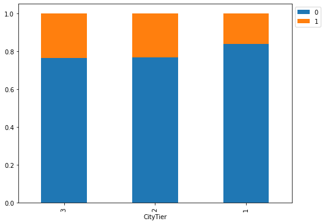

```python
stacked_barplot(df, "CityTier", 'ProdTaken')
```

#### Observation

- Customers from City Tiers 3 and 2 bought a travel package at higher rates than customers from tier 1 cities though just looking at customers who bought a travel package, 57% were from CityTier 1

#### PreferredPropertyStar

```
ProdTaken                 0    1   All
PreferredPropertyStar
All                    3968  920  4888
3                      2531  488  3019
5                       706  250   956
4                       731  182   913
------------------------------------------------------------------------------------------------------------------------
```

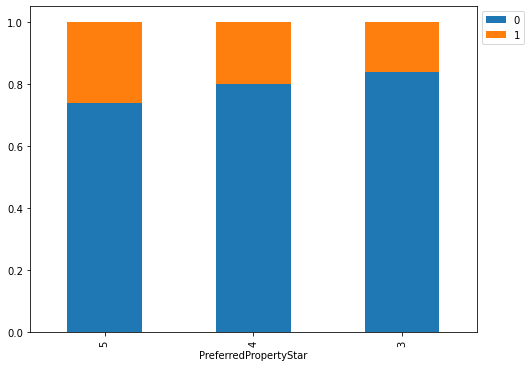

```python
stacked_barplot(df, "PreferredPropertyStar", 'ProdTaken')
```

#### Observation

- Customers who preferred 5 and 4 star hotels were more likely to purchase a travel package
- Among the 920 customers who bought a travel package, most of them, 53%, reported preferrence for a 3 star hotel

#### PitchSatisfactionScore

```
ProdTaken                  0    1   All
PitchSatisfactionScore
All                     3968  920  4888
3                       1162  316  1478
5                        760  210   970
4                        750  162   912
1                        798  144   942
2                        498   88   586
------------------------------------------------------------------------------------------------------------------------
```

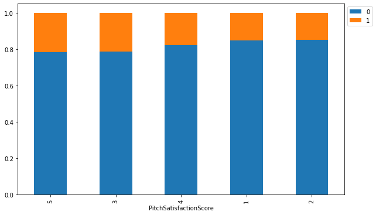

```python
stacked_barplot(df, "PitchSatisfactionScore", 'ProdTaken')
```

##### Observation

- Customers more satified with the sales pitch purchased a travel package at higher rates than customers less satified

#### Gender

```
ProdTaken     0    1   All
Gender
All        3968  920  4888
Male       2338  578  2916
Female     1630  342  1972
------------------------------------------------------------------------------------------------------------------------
```

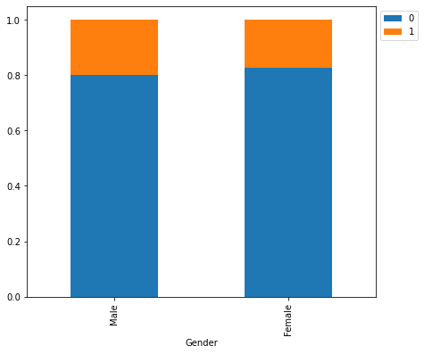

```python
stacked_barplot(df, "Gender", 'ProdTaken')
```

##### Observation

- Not much difference observed in terms of gender and product purchase

#### MaritalStatus

```
ProdTaken         0    1   All
MaritalStatus
All            3968  920  4888
Married        2014  326  2340
Single          612  304   916
Unmarried       516  166   682
Divorced        826  124   950
------------------------------------------------------------------------------------------------------------------------
```

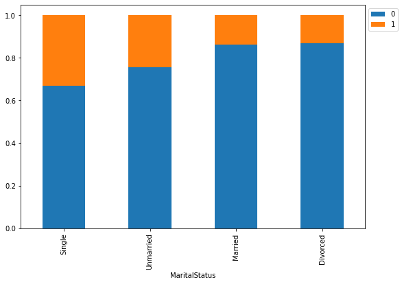

```python
stacked_barplot(df, "MaritalStatus", 'ProdTaken')
```

##### Observation

- Single and Unmarried customers purchased a travel package at greater proportions than those married and divorced

#### Occupation

```
ProdTaken          0    1   All
Occupation
All             3968  920  4888
Salaried        1954  414  2368
Small Business  1700  384  2084
Large Business   314  120   434
Free Lancer        0    2     2
------------------------------------------------------------------------------------------------------------------------
```

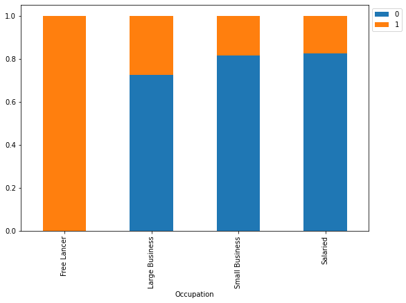

```python
stacked_barplot(df, "Occupation", 'ProdTaken')
```

##### Observation

- The graph is being distorted by the 2 customers whose occupation is reported as free-lancer - these 2 happened to purchase a travel package giving us the false impression, through this graph, that free-lancers are highly inclined to purchase a travel package
- Among the customers who bought a travel package, most were in the Salaried category

#### Designation

```
ProdTaken          0    1   All
Designation
All             3968  920  4888
Executive       1290  552  1842
Manager         1528  204  1732
Senior Manager   618  124   742
AVP              322   20   342
VP               210   20   230
------------------------------------------------------------------------------------------------------------------------
```

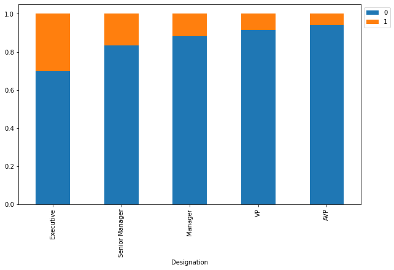

```python
stacked_barplot(df, "Designation", 'ProdTaken')
```

```python
df.groupby(['Designation']).agg({'MonthlyIncome': ['mean', 'min', 'median', 'max']})
```

| Designation | MonthlyIncome mean | MonthlyIncome min | MonthlyIncome median | MonthlyIncome max |
| --- | --- | --- | --- | --- |
| AVP | 32241.046784 | 17705.0 | 32181.0 | 37502.0 |
| Executive | 20053.611835 | 16009.0 | 20766.0 | 98678.0 |
| Manager | 22618.192841 | 1000.0 | 22678.0 | 38525.0 |
| Senior Manager | 26637.749326 | 17372.0 | 26425.0 | 38395.0 |
| VP | 35878.947826 | 17517.0 | 34999.0 | 38677.0 |

##### Observation

- Customers reporting designation as "Executive" purchased a travel package at a higher proportion than in other designation categories
- Looking at a breakdown of salaries among the different designation categories, it looks like Executive designation is at the bottom of the monthly income level for this dataset - meaning that, proportionally, it looks like travel packages were more likely to be purchased among customers who made less per year than those who earned higher income

#### Passport

```
ProdTaken     0    1   All
Passport
All        3968  920  4888
1           928  494  1422
0          3040  426  3466
------------------------------------------------------------------------------------------------------------------------
```

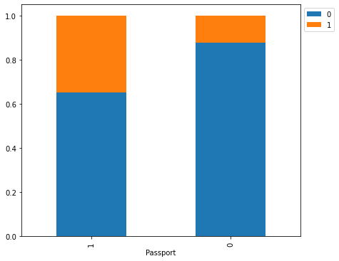

```python
stacked_barplot(df, "Passport", 'ProdTaken')
```

##### Observation

- Among customers who own a passport, travel packages were sold at higher rates than among people who did not have a passport

#### OwnCar

```
ProdTaken     0    1   All
OwnCar
All        3968  920  4888
1          2472  560  3032
0          1496  360  1856
------------------------------------------------------------------------------------------------------------------------
```

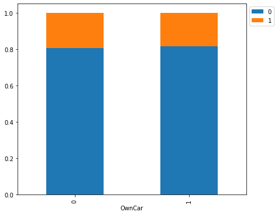

```python
stacked_barplot(df, "OwnCar", 'ProdTaken')
```

##### Observation

- Customers who own and who do not own a car seemed to have purchased a travel package at similar rates

#### ProductPitched

```
ProdTaken          0    1   All
ProductPitched
All             3968  920  4888
Basic           1290  552  1842
Deluxe          1528  204  1732
Standard         618  124   742
King             210   20   230
Super Deluxe     322   20   342
------------------------------------------------------------------------------------------------------------------------
```

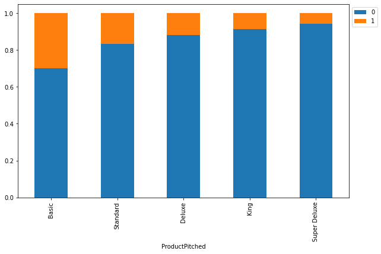

```python
stacked_barplot(df, "ProductPitched", 'ProdTaken')
```

##### Observation

- Purchase of a travel package happened at a greater rate (30%) among customers pitched the Basic package
- We observe much lower conversion rates among customers pitched the King (8.6%) and Super Deluxe (5.8%) packages

#### TypeofContact

```
ProdTaken           0    1   All
TypeofContact
All              3968  920  4888
Self Enquiry     2859  610  3469
Company Invited  1109  310  1419
------------------------------------------------------------------------------------------------------------------------
```

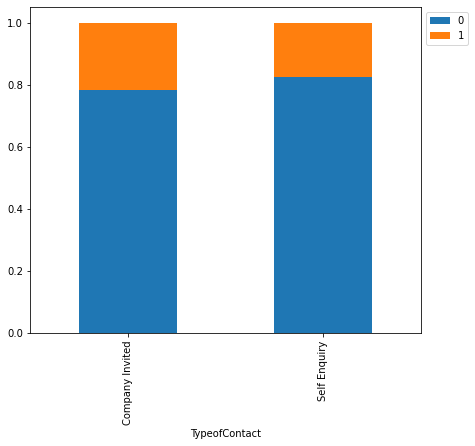

```python
stacked_barplot(df, "TypeofContact", 'ProdTaken')
```

##### Observations

- We observe a slightly greater proportion of sales among company-invited customers (approached by Visit With Us) though most sales came from self-inquiring customers

##### Please note

- A detailed summary of observations from EDA provided below

### Examining customer characteristics by product package

Filtering dataframe to include travel package buyers only to more easily observe customer characteristics by product type

```python
df1 = df.query('ProdTaken == 1')
```

```python
df1.drop("ProdTaken", axis=1, inplace=True)
```

```python
print(df1["ProductPitched"].value_counts())
print('-'*30)
print((df1["ProductPitched"].value_counts()/len(df1))*100)
```

```
Basic           552
Deluxe          204
Standard        124
King             20
Super Deluxe     20
Name: ProductPitched, dtype: int64
------------------------------
Basic           60.000000
Deluxe          22.173913
Standard        13.478261
King             2.173913
Super Deluxe     2.173913
Name: ProductPitched, dtype: float64
```

#### Product Pitched and Age

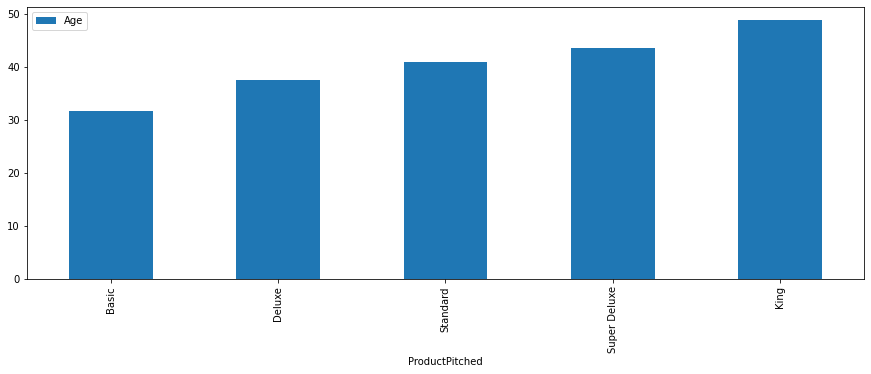

```python
df1.groupby(by=['ProductPitched'])['Age'].mean().reset_index().sort_values(['Age']
, ascending=True).plot(x='ProductPitched', y='Age', kind='bar', figsize=(15,5))
plt.show()
```

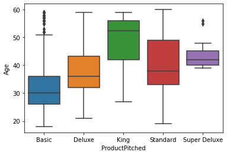

```python
# Relationship between travel package purchased and age

sns.boxplot(df1.ProductPitched, df1.Age);
```

##### Observation

- Purchasers who were pitched the Basic package tended to be younger

#### Product Pitched and DurationOfPitch

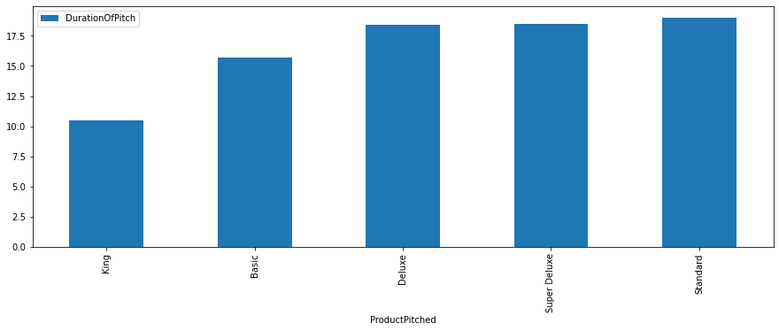

```python
df1.groupby(by=['ProductPitched'])['DurationOfPitch'].mean().reset_index().sort_values(['DurationOfPitch']
, ascending=True).plot(x='ProductPitched', y='DurationOfPitch', kind='bar', figsize=(15,5))
plt.show()
```

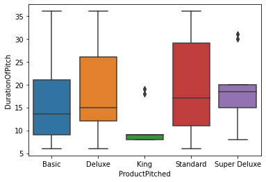

```python
# Relationship between travel package purchased and DurationOfPitch

sns.boxplot(df1.ProductPitched, df1.DurationOfPitch);
```

##### Observation

- Duration of pitch for buyers who were pitched the Basic package were generally shorter than for buyers pitched Deluxe and Standard packages

#### Product Pitched and Monthly Income

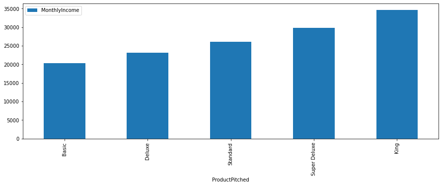

```python
df1.groupby(by=['ProductPitched'])['MonthlyIncome'].mean().reset_index().sort_values(['MonthlyIncome'], ascending=True).plot(x='ProductPitched', y='MonthlyIncome', kind='bar', figsize=(15,5))
plt.show()
```

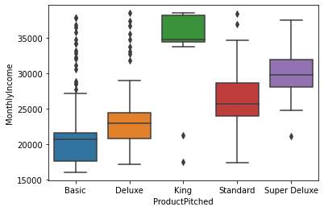

```python
# Relationship between travel package purchased and monthly income

sns.boxplot(df1.ProductPitched, df1.MonthlyIncome);
```

##### Observation

- As expected, monthly income of customers who were pitched the more higher end travel packages tended to be higher than monthly income of purchasers pitched the Basic package

#### Product Pitched and NumberOfPersonVisiting

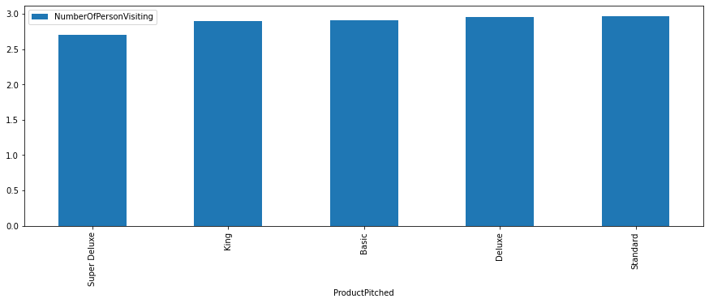

```python
df1.groupby(by=['ProductPitched'])['NumberOfPersonVisiting'].mean().reset_index().sort_values(['NumberOfPersonVisiting']
, ascending=True).plot(x='ProductPitched', y='NumberOfPersonVisiting', kind='bar', figsize=(15,5))
plt.show()
```

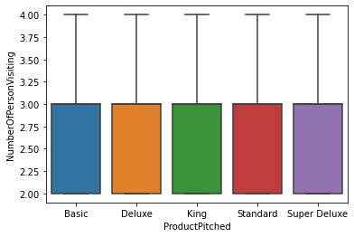

```python
# Relationship between travel package purchased and NumberOfPersonVisiting

sns.boxplot(df1.ProductPitched, df1.NumberOfPersonVisiting);
```

##### Observation

- We do not observe much difference between purchasers pitched different travel packages and the expected number of people travelling with these customers

#### Product Pitched and NumberOfFollowups

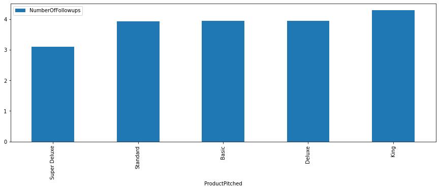

```python
df1.groupby(by=['ProductPitched'])['NumberOfFollowups'].mean().reset_index().sort_values(['NumberOfFollowups']
, ascending=True).plot(x='ProductPitched', y='NumberOfFollowups', kind='bar', figsize=(15,5))
plt.show()
```

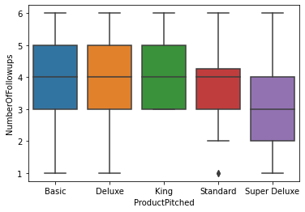

```python
# Relationship between travel package purchased and NumberOfFollowups

sns.boxplot(df1.ProductPitched, df1.NumberOfFollowups);
```

#### Observation

- Number of follow ups for buyers pitched Basic and Deluxe packages did not seem to differ. We observe a narrower range for the distribution of mid 50% number of follow ups for customers pitched the Standard package

#### Product Pitched and NumberOfTrips

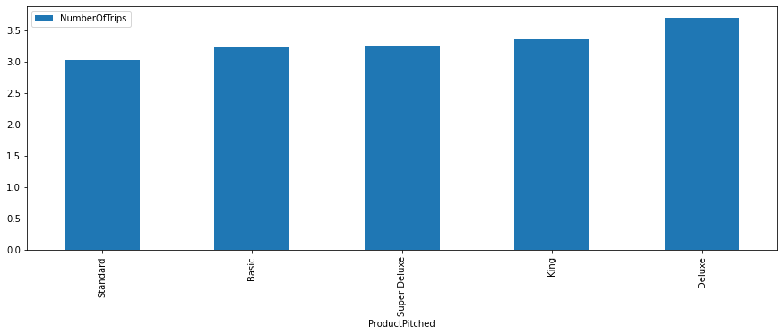

```python
df1.groupby(by=['ProductPitched'])['NumberOfTrips'].mean().reset_index().sort_values(['NumberOfTrips']
, ascending=True).plot(x='ProductPitched', y='NumberOfTrips', kind='bar', figsize=(15,5))
plt.show()
```

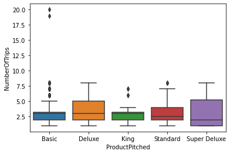

```python
# Relationship between travel package purchased and NumberOfTrips

sns.boxplot(df1.ProductPitched, df1.NumberOfTrips);
```

##### Observation

- It looks like buyers who were pitched the Deluxe package reported being more avid travellers, with a higher average number of trips per year, than customer pitched the other travel packages

#### Product Pitched and NumberOfChildrenVisiting

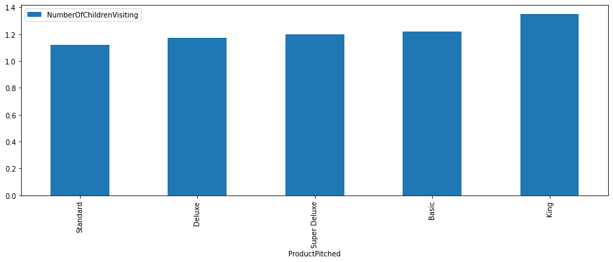

```python
df1.groupby(by=['ProductPitched'])['NumberOfChildrenVisiting'].mean().reset_index().sort_values(['NumberOfChildrenVisiting']
, ascending=True).plot(x='ProductPitched', y='NumberOfChildrenVisiting', kind='bar', figsize=(15,5))
plt.show()
```

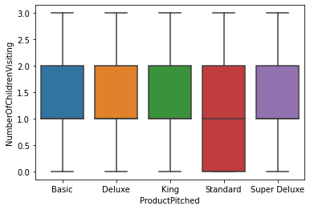

```python
# Relationship between travel package purchased and NumberOfChildrenVisiting

sns.boxplot(df1.ProductPitched, df1.NumberOfChildrenVisiting);
```

#### Observation

- We do not observe much difference in terms of the number of children planned to travel along between buyers pitched different packages

#### Product Pitched and CityTier

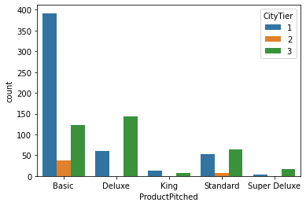

```python
sns.countplot(df1.ProductPitched, hue=df1.CityTier);
```

#### Observation

- We observe a larger number of buyers pitched the Basic package from CityTier 1
- We also observe a larger number of buyers from CityTier 3 who were pitched the Deluxe package vs the Basic package

#### Product Pitched and PreferredPropertyStar

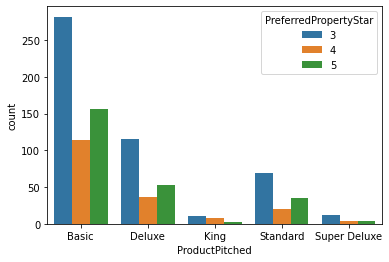

```python
sns.countplot(df1.ProductPitched, hue=df1.PreferredPropertyStar.astype(int));
```

##### Observation

- Though we do not observe greatly different patterns in terms of preferred property stars between customers pitched different travel packages, buyers pitched the Basic package seem to prefer hotels rated at 3 start more so than customers pitched other packages

#### Product Pitched and PitchSatisfactionScore

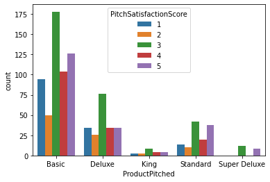

```python
sns.countplot(df1.ProductPitched, hue=df1.PitchSatisfactionScore.astype(int));
```

##### Observation

- In general, all buyers, regardless of product pitched, rated satisfaction with pitch most often at a 3

#### Product Pitched and Gender

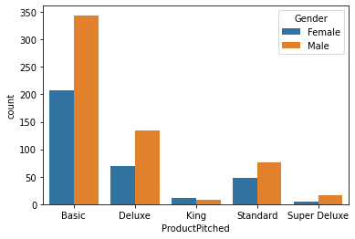

```python
sns.countplot(df1.ProductPitched, hue=df1.Gender);
```

##### Observation

- It looks like buyers, both male and female, were pitched the Basic package and Deluxe at higher rates than other packages

#### Product Pitched and Marital Status

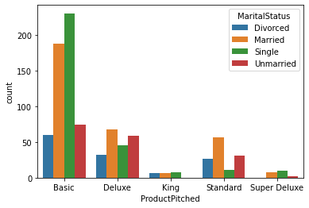

```python
sns.countplot(df1.ProductPitched, hue=df1.MaritalStatus);
```

##### Observation

- Buyers who were single were pitched the Basic package at higher rates than other buyers

#### Product Pitched and Occupation

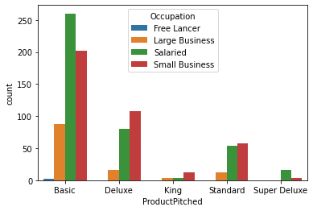

```python
sns.countplot(df1.ProductPitched, hue=df1.Occupation);
```

##### Observation

- We observe similar patterns in terms of product pitched for buyers in different occupations

#### Product Pitched and Designation

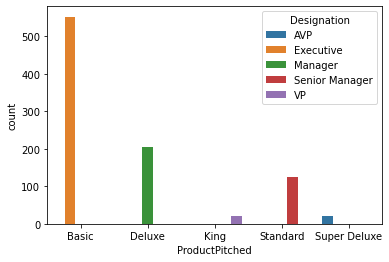

```python
sns.countplot(df1.ProductPitched, hue=df1.Designation);
```

##### Observation

- It looks like Basic package was only pitched to buyers reported as Designation "Executive", Deluxe package only pitched to buyers reported as "Manager", Standard only pitched to buyers reported as "Senior Manager", King pitched only to "VPs" and "Super Deluxed" pitched only to "AVPs"

#### Product Pitched and Passport

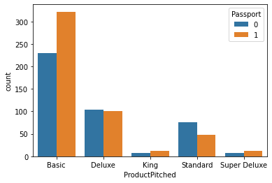

```python
sns.countplot(df1.ProductPitched, hue=df1.Passport);
```

##### Observation

- It looks like conversion rates were highest among buyers who have a passport and were pitched the Basic package - the opposite pattern observed for buyers who were pitched the Standard package

#### Product Pitched and OwnCar

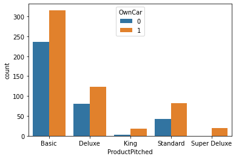

```python
sns.countplot(df1.ProductPitched, hue=df1.OwnCar);
```

##### Observation

- Patterns of product pitched look similar for buyers who own and do not own a car

#### Product Pitched and TypeofContact

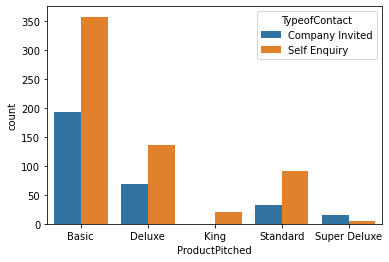

```python
sns.countplot(df1.ProductPitched, hue=df1.TypeofContact);
```

## Handling outliers

```python
num_features = ["Age"
                , "DurationOfPitch"
                , "NumberOfPersonVisiting"
                , "NumberOfFollowups"
                , "NumberOfTrips"
                , "NumberOfChildrenVisiting"
                , "PitchSatisfactionScore"
                , "MonthlyIncome"]
```

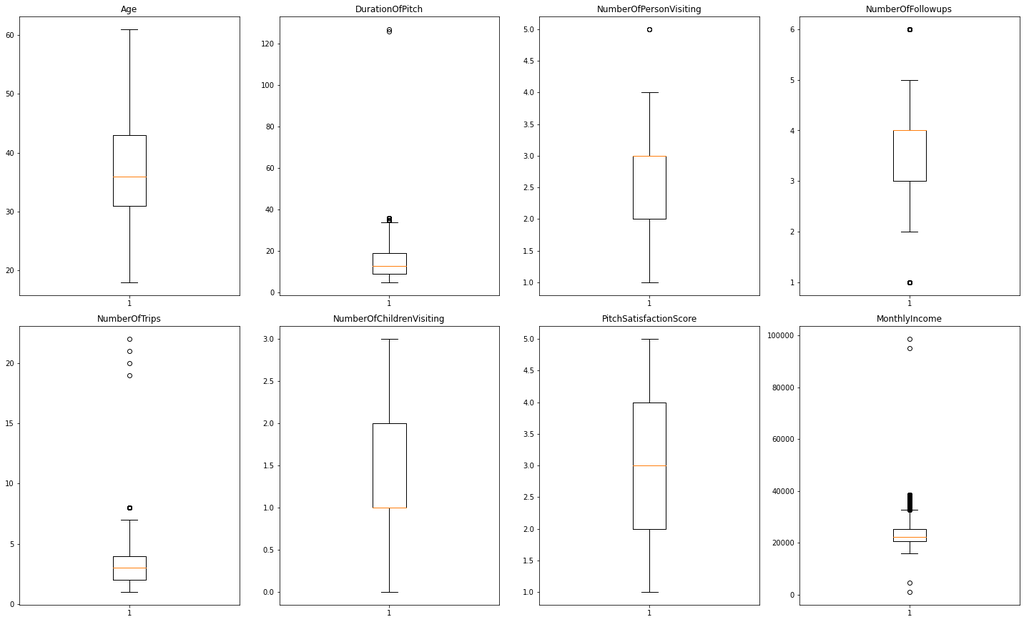

```python
# let's look at box plot to see if outliers have been treated or not
plt.figure(figsize=(20, 30))

for i, variable in enumerate(num_features):
    plt.subplot(5, 4, i + 1)
    plt.boxplot(df[variable], whis=1.5)
    plt.tight_layout()
    plt.title(variable)

plt.show()
```

```python
outlier_features = [
                "DurationOfPitch"
                , "NumberOfPersonVisiting"
                , "NumberOfFollowups"
                , "NumberOfTrips"
                , "MonthlyIncome"]
```

```python
# Let's treat outliers by flooring and capping
def treat_outliers(df, col):
    """
    treats outliers in a variable
    col: str, name of the numerical variable
    df: dataframe
    col: name of the column
    """
    Q1 = df[col].quantile(0.25)  # 25th quantile
    Q3 = df[col].quantile(0.75)  # 75th quantile
    IQR = Q3 - Q1
    Lower_Whisker = Q1 - 1.5 * IQR
    Upper_Whisker = Q3 + 1.5 * IQR

    # all the values smaller than Lower_Whisker will be assigned the value of Lower_Whisker
    # all the values greater than Upper_Whisker will be assigned the value of Upper_Whisker
    df[col] = np.clip(df[col], Lower_Whisker, Upper_Whisker)

    return df


def treat_outliers_all(df, col_list):
    """
    treat outlier in all numerical variables
    col_list: list of numerical variables
    df: data frame
    """
    for c in col_list:
        df = treat_outliers(df, c)

    return df
```

```python
df = treat_outliers_all(df, outlier_features)
```

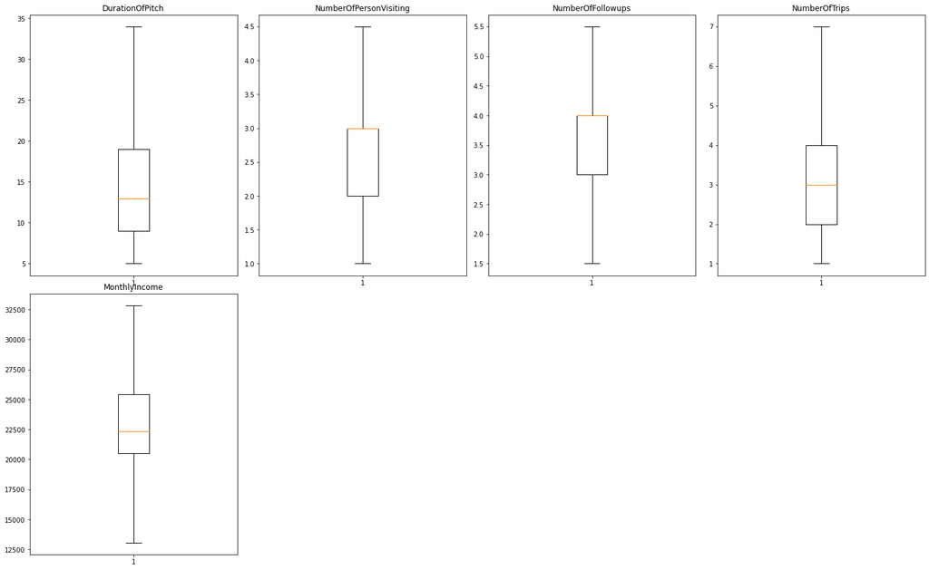

```python
plt.figure(figsize=(20, 30))

for i, variable in enumerate(outlier_features):
    plt.subplot(5, 4, i + 1)
    plt.boxplot(df[variable], whis=1.5)
    plt.tight_layout()
    plt.title(variable)

plt.show()
```

#### Observation

- Outliers successfully treated

### Transforming categorical and ordinal features to numeric values for model-building purposes

#### Examining value counts for categorical and ordinal features

```python
print(df.TypeofContact.value_counts())
print('-'*30)
print(df.Occupation.value_counts())
print('-'*30)
print(df.Gender.value_counts())
print('-'*30)
print(df.ProductPitched.value_counts())
print('-'*30)
print(df.MaritalStatus.value_counts())
print('-'*30)
print(df.Designation.value_counts())
print('-'*30)
```

```
Self Enquiry       3469
Company Invited    1419
Name: TypeofContact, dtype: int64
------------------------------
Salaried          2368
Small Business    2084
Large Business     434
Free Lancer          2
Name: Occupation, dtype: int64
------------------------------
Male      2916
Female    1972
Name: Gender, dtype: int64
------------------------------
Basic           1842
Deluxe          1732
Standard         742
Super Deluxe     342
King             230
Name: ProductPitched, dtype: int64
------------------------------
Married      2340
Divorced      950
Single        916
Unmarried     682
Name: MaritalStatus, dtype: int64
------------------------------
Executive         1842
Manager           1732
Senior Manager     742
AVP                342
VP                 230
Name: Designation, dtype: int64
------------------------------
```

##### Observation

- We observe 2 outlier values for Occupation feature for the category "Free Lancer" - these two values will be altered to be counted among the most frequent value in the Occupation distribution, "Salaried"

In order to transform the features above to numeric values for model-building purposes

- We will apply One-Hot Encoding to the categorical features that are not ordinal: TypeofContact, Occupation, Gender, and MaritalStatus.
- We will apply Label Encoding to the categorical features that are ordinal: Designation and ProductPitched

```python
#Replacing "Free Lancer" category in Occupation for "Salaried"
df["Occupation"].replace({"Free Lancer": "Salaried"}, inplace=True)
```

```python
#Looking at MonthlyIncome by Designation position to ensure ordinal values are coded correctly
df.groupby(['Designation']).agg({'MonthlyIncome': ['mean', 'min', 'median', 'max']})
```

| Designation | MonthlyIncome mean | MonthlyIncome min | MonthlyIncome median | MonthlyIncome max |
| --- | --- | --- | --- | --- |
| AVP | 31411.244883 | 17705.000 | 32181.000 | 32834.375 |
| Executive | 19970.070847 | 16009.000 | 20766.000 | 32834.375 |
| Manager | 22618.381856 | 13075.375 | 22678.000 | 32834.375 |
| Senior Manager | 26621.600404 | 17372.000 | 26425.000 | 32834.375 |
| VP | 32717.171739 | 17517.000 | 32834.375 | 32834.375 |

##### Observation

- Using MonthlyIncome as a proxy for job role rank we will code Designation as follows (breakdown of monthly income averages by job designation above): VP (highest average income) > AVP (second to highest average income) > Senior Manager > Manager > Executive (lowest average income)

```python
replaceStruct = {
                "ProductPitched": {"Basic": 1, "Standard":2 , "Deluxe": 3, "Super Deluxe": 4, "King":5},
                 "Designation": {"Executive": 1 ,"Manager": 2, "Senior Manager": 3, "AVP": 4, "VP": 5},
                    }
oneHotCols=["TypeofContact","Occupation","Gender","MaritalStatus"]
```

```python
#Label encoding done for ProductPitched and Designation:
df =df.replace(replaceStruct)

#One-Hot encoding done for TypeofContact, Occupation, Gender, and MaritalStatus
df=pd.get_dummies(df, columns=oneHotCols,drop_first=True)
df.head(10)
```

|  | ProdTaken | Age | CityTier | DurationOfPitch | NumberOfPersonVisiting | NumberOfFollowups | ProductPitched | PreferredPropertyStar | NumberOfTrips | Passport | ... | NumberOfChildrenVisiting | Designation | MonthlyIncome | TypeofContact_Self Enquiry | Occupation_Salaried | Occupation_Small Business | Gender_Male | MaritalStatus_Married | MaritalStatus_Single | MaritalStatus_Unmarried |
| --- | --- | --- | --- | --- | --- | --- | --- | --- | --- | --- | --- | --- | --- | --- | --- | --- | --- | --- | --- | --- | --- |
| 0 | 1 | 41 | 3 | 6.0 | 3.0 | 3.0 | 3 | 3 | 1 | 1 | ... | 0 | 2 | 20993.0 | 1 | 1 | 0 | 0 | 0 | 1 | 0 |
| 1 | 0 | 49 | 1 | 14.0 | 3.0 | 4.0 | 3 | 4 | 2 | 0 | ... | 2 | 2 | 20130.0 | 0 | 1 | 0 | 1 | 0 | 0 | 0 |
| 2 | 1 | 37 | 1 | 8.0 | 3.0 | 4.0 | 1 | 3 | 7 | 1 | ... | 0 | 1 | 17090.0 | 1 | 1 | 0 | 1 | 0 | 1 | 0 |
| 3 | 0 | 33 | 1 | 9.0 | 2.0 | 3.0 | 1 | 3 | 2 | 1 | ... | 1 | 1 | 17909.0 | 0 | 1 | 0 | 0 | 0 | 0 | 0 |
| 4 | 0 | 36 | 1 | 8.0 | 2.0 | 3.0 | 1 | 4 | 1 | 0 | ... | 0 | 1 | 18468.0 | 1 | 0 | 1 | 1 | 0 | 0 | 0 |
| 5 | 0 | 32 | 1 | 8.0 | 3.0 | 3.0 | 1 | 3 | 1 | 0 | ... | 1 | 1 | 18068.0 | 0 | 1 | 0 | 1 | 0 | 1 | 0 |
| 6 | 0 | 59 | 1 | 9.0 | 2.0 | 2.0 | 1 | 5 | 5 | 1 | ... | 1 | 1 | 17670.0 | 1 | 0 | 1 | 0 | 0 | 0 | 0 |
| 7 | 0 | 30 | 1 | 30.0 | 3.0 | 3.0 | 1 | 3 | 2 | 0 | ... | 1 | 1 | 17693.0 | 1 | 1 | 0 | 1 | 1 | 0 | 0 |
| 8 | 0 | 38 | 1 | 29.0 | 2.0 | 4.0 | 2 | 3 | 1 | 0 | ... | 0 | 3 | 24526.0 | 0 | 1 | 0 | 1 | 0 | 0 | 1 |
| 9 | 0 | 36 | 1 | 33.0 | 3.0 | 3.0 | 3 | 3 | 7 | 0 | ... | 0 | 2 | 20237.0 | 1 | 0 | 1 | 1 | 0 | 0 | 0 |

10 rows × 22 columns

### Converting non-float numeric columns to integer values

- Whole numbers expected from features below

```python
# Outlier treatment resulted in reverting integers back to float numbers, the code below used to correct that
df["Age"] = df["Age"].astype(int)
df["NumberOfPersonVisiting"] = df["NumberOfPersonVisiting"].astype(int)
df["NumberOfFollowups"] = df["NumberOfFollowups"].astype(int)
df["PreferredPropertyStar"] = df["PreferredPropertyStar"].astype(int)
df["NumberOfTrips"] = df["NumberOfTrips"].astype(int)
df["NumberOfChildrenVisiting"] = df["NumberOfChildrenVisiting"].astype(int)
```

```python
df.info()
```

```
<class 'pandas.core.frame.DataFrame'>
RangeIndex: 4888 entries, 0 to 4887
Data columns (total 22 columns):
 #   Column                      Non-Null Count  Dtype
---  ------                      --------------  -----
 0   ProdTaken                   4888 non-null   int64
 1   Age                         4888 non-null   int64
 2   CityTier                    4888 non-null   int64
 3   DurationOfPitch             4888 non-null   float64
 4   NumberOfPersonVisiting      4888 non-null   int64
 5   NumberOfFollowups           4888 non-null   int64
 6   ProductPitched              4888 non-null   int64
 7   PreferredPropertyStar       4888 non-null   int64
 8   NumberOfTrips               4888 non-null   int64
 9   Passport                    4888 non-null   int64
 10  PitchSatisfactionScore      4888 non-null   int64
 11  OwnCar                      4888 non-null   int64
 12  NumberOfChildrenVisiting    4888 non-null   int64
 13  Designation                 4888 non-null   int64
 14  MonthlyIncome               4888 non-null   float64
 15  TypeofContact_Self Enquiry  4888 non-null   uint8
 16  Occupation_Salaried         4888 non-null   uint8
 17  Occupation_Small Business   4888 non-null   uint8
 18  Gender_Male                 4888 non-null   uint8
 19  MaritalStatus_Married       4888 non-null   uint8
 20  MaritalStatus_Single        4888 non-null   uint8
 21  MaritalStatus_Unmarried     4888 non-null   uint8
dtypes: float64(2), int64(13), uint8(7)
memory usage: 606.4 KB
```

# Summary of EDA and Data Pre-Processing for Model Building

**Data Description:**

**Data Cleaning:**

- CustomerID is an ID variable so it was dropped from the data.
- All the features with missing values were carefully examined to assess the best approach for inputting missing values. Median value inputed for DurationOfPitch, MonthlyIncome, and Age missing values. Mean value inputed for missing values in NumberOfTrips, NumberOfChildrenVisiting, NumberOfFollowups, PreferredPropertyStar. TypeOfContact missing values filled with its most frequent value, "Self-Enquiry"
- Gender had 3 different values: Male, Female, and Fe Male. The latter, a total of 155 values, was cleaned up and added to the Female category
- Outliers were observed and treated for the features "DurationOfPitch", "NumberOfPersonVisiting", "NumberOfFollowups", "NumberOfTrips", and "MonthlyIncome"
- We also observed 2 outlier values for Occupation feature for the category "Free Lancer" - these two values were altered to be counted among the most frequent value in the Occupation distribution, "Salaried"

**Observations from EDA:**

###### Univariate Analysis

- `Age`: The mean and median age of Visit With Us customer hover around late 30s - mean of 37.5 and median of 36
- `Duration of pitch`: We observe a right-skewness in the data given presence of large value outliers
- `Monthly Income`: Mean and median annual income hovering around 23K. We observe the presence of outliers on both sides of the value distribution
- `Number Of Person Visiting`: The most frequent value observed for number of people intended to be travelling with customer is 3 followed by 2. Very few customers said they intended to take trip with just 1 person
- `Number Of Followups`: Over 70% of customers received 3 to 4 follow ups from Visit With Us sales team
- `Number of Trips`: Over 50% of customers reported taking on average 2 to 3 trips per year
- `Number of Children Visiting`: 44% of customers reported planning to travel with 1 small child (age less than 5)
- `City Tier`: Metadata describes "CityTier" as depending on the development of a city, population, facilities, and living standards. The categories are ordered i.e. Tier 1 > Tier 2 > Tier 3. The most frequent CityTier reported here as Tier 1 - unsure if this is the intended travel destination or reported demographic information related to customer residence
- `Preferred Property Star`: The most popular preferred hotel property rating by customers is 3 stars
- `Pitch Satisfaction Score`: Most common rating for sales pitch satisfaction was 3. Near 70% of customers rated sales pitch from 3 to 5
- `Gender`: Close to 60% of customers are male
- `Marital Status`: Nearly 50% of all customers in dataset are married
- `Occupation`: Most customers are salaried professionals. 2 customers reported as free lancers
- `Designation`: Most customers reported being Executives (nearly 40%) followed by managers (35%)
- `Passport`: 70% of customers report not having a passport
- `Own car`: 62% of customers report having a car
- `Product Pitched`: The most often pitched travel package was the Basic (38%) followed by the Deluxe (35%). Packages ordered as Basic, Standard, Deluxe, Super Deluxe, King (see data pre-processing details below)
- `Type of Contact`: 71% of customers reported approaching Visit With Us with travel inquiries rather than being first contacted by company
- `ProdTaken`(target variable): Close to 19% of customers bought a Visit With Us travel package

###### Bivariate Analysis

Examining relationships between features and target variable

**Correlations** between target variable and numeric features:

- We do not observe correlations between the features 'MonthlyIncome', 'Age','DurationOfPitch','NumberOfPersonVisiting', 'NumberOfFollowups', 'NumberOfTrips', 'NumberOfChildrenVisiting','PitchSatisfactionScore' and the target variable, 'ProdTaken'
- The highest ProdTaken correlation values being very mild negative correlations, -0.13 and -0.14 with Monthly Income and Age, respectively
- `Age and Target Variable`: age distribution for those who bought a travel package is slightly lower (meaning purchasers are in general younger) than for those who did not buy
- `Duration of pitch and Target Variable`: we observe that duration of sales pitch was on average longer for customers who purchased a travel package
- `Monthly Income and Target Variable`: we observe a monthly income distribution at lower income levels for customers who purchased a travel package
- `Number Of Person Visiting and Target Variable`: Customers who planned to travel with 2 to 4 people bought a travel package at greater proportions than customers who indicated plans to travel with 1 or 5 people
- `Number Of Followups and Target Variable`: more follow ups were related to greater sales though we cannot conclude more follow ups resulted in more sales
- `Number of Trips and Target Variable`: of customers who reported average trips/year between 1 and 8, we see that those who reported greater number of average trips annually also tended to purchase a travel package in greater proportion
- `Number of Children Visiting and Target Variable`: customers who purchased a travel package did not differ much from non-buyers in terms of number of children travelling though among those who bought travel package, over 70% planned to travel with 1 or 2 children
- `City Tier and Target Variable`: Customers from City Tiers 3 and 2 bought a travel package at higher rates than customers from tier 1 cities though just looking at customers who bought a travel package, 57% were from CityTier 1
- `Preferred Property Star and Target Variable`: customers who preferred 5 and 4 star hotels were more likely to purchase a travel package. Among the 920 customers who bought a travel package, most of them, 53%, reported preferrence for a 3 star hotel
- `Pitch Satisfaction Score and Target Variable`: customers more satified with the sales pitch purchased a travel package at higher rates than customers less satified
- `Gender and Target Variable`: not much difference observed in terms of gender and product purchase
- `Marital Status and Target Variable`: single and Unmarried customers purchased a travel package at greater proportions than those married and divorced
- `Occupation and Target Variable`: among customers who bought a travel package, most were in the Salaried category
- `Designation and Target Variable`: customers reporting designation as "Executive" purchased a travel package at a higher proportion than in other designation categories. Looking at a breakdown of salaries among the different designation categories, it looks like Executive designation is at the bottom of the monthly income level for this dataset - meaning that it looks like travel packages were more likely to be purchased by customers who made less per year than by those who earned higher income
- `Passport and Target Variable`: among customers who own a passport, travel packages were sold at higher rates than among people who did not have a passport
- `Own car and Target Variable`: customers who own and who do not own a car seemed to have purchased a travel package at similar rates
- `Product Pitched and Target Variable`: purchase of a travel package occurred at a greater rate (30%) among customers pitched the Basic package. We observe much lower conversion rates among customers pitched the King (8.6%) and Super Deluxe (5.8%) packages
- `Type of Contact and Target Variable`: we observe a slightly greater proportion of sales among company-invited customers (approached by Visit With Us) though most sales came from self-inquiring customers

##### Customer Profiles by Product Pitched

Here dataframe was filtered to include travel package buyers only to more easily observe customer characteristics by travel packaged pitched

BASIC PACKAGE:

- Most popular travel package
- Customer base made primarily of single adults in their early to mid 30s
- Salaried professionals with monthly income at the lower-end of the scale compared to other customers, approximately 20k
- Basic package customers tend to reside in larger, more developed cities (CityTier 1)
- They have passports and show eagerness to travel, taking 3 trips per year on average
- Customers in this category tend to approach Visit With Us - most initial contact done through self-inquiry

DELUXE PACKAGE:

- The most travel-eager customer of the group, taking 3.5 trips per year on average
- Professionals in their late 30s and 40s, mostly married or with a partner ("Unmarried")
- Compared to other customer groups, Deluxe customers on average tended to take longer to be persuaded to purchase and/or need more assistance from sales
- Salaried and professionals working for small businesses making about 23k/month
- Mostly residents of smaller cities, with less facilities and lower standard of living (CityTier 3)
- Customers here also tended to approach Visit With Us - most contact done through self-inquiry

STANDARD PACKAGE:

- The 3rd most popular of the 5 travel packages
- Customers in this group tended not to own a passport and be less prone to travel than other customers - perhaps also that is why duration of pitch was on average the longest for this group
- Group consisting of salaried and professionals working for mostly small businesses. Monthly income around 25k
- Customers in their late 30s to late 40s, mostly married and residing in CityTier 3 cities (smaller, less facilities)

SUPER DELUXE AND KING: **Important**: merging the 2 customer groups into a single customer profile category given the low number (2% of total buyers for each) of customers in these categories

- The oldest age set among Visit With Us customers consisting of customers in their late 40s and 50s
- Advanced career professionals (VPs and AVPs) with monthly income at 30 to 35k
- They tend to own a passport and report taking on average 3 trips/year

**Actions for data pre-processing:**

- ProductPitched and Designation features were assigned numeric values indicating ordinal levels as follows: **ProductPitched**: King (5) > Super Deluxe (4) > Deluxe (3) > Standard (2) > Basic (1) **Designation** (based on monthly income levels): VP (5) > AVP (4) > Senior Manager (3) > Manager (2) > Executive (1)
- One-Hot encoding was used to create dummy variables for TypeofContact, Occupation, Gender and Marital Status
- Outliers, non-sensical, and missing values all treated to prepare data for model building
- All features transformed in numeric data types for model building purposes

## Model Building - Approach

1. Data preparation
2. Partition the data into train and test set.
3. Build model on the train data.
4. Tune the model if required.
5. Test the data on test set.

## Split Data

- When classification problems exhibit a significant imbalance in the distribution of the target classes, it is good to use stratified sampling to ensure that relative class frequencies are approximately preserved in train and test sets.
- This is done using the `stratify` parameter in the train_test_split function.

```python
X = df.drop(["ProdTaken"], axis=1)
y = df.pop("ProdTaken")
```

**The Stratify arguments maintain the original distribution of classes in the target variable while splitting the data into train and test sets.**

```python
y.value_counts()/len(y)
```

```
0    0.811784
1    0.188216
Name: ProdTaken, dtype: float64
```

```python
# Splitting data into training and test set:
X_train, X_test, y_train, y_test =train_test_split(X, y, test_size=0.3, random_state=1,stratify=y)
print(X_train.shape, X_test.shape)
```

```
(3421, 21) (1467, 21)
```

```python
y_train.value_counts()/len(y_train)
```

```
0    0.811751
1    0.188249
Name: ProdTaken, dtype: float64
```

```python
y_test.value_counts()/len(y_test)
```

```
0    0.811861
1    0.188139
Name: ProdTaken, dtype: float64
```

## Model evaluation criterion

### Goal of the model

- To recap, the goal is to build a model that will help the Policy Maker and Marketing Teamt predict which customer is more likely to purchase the newly introduced travel package (Wellness Tourism Package)

For the predictive model it is important to remember the following in terms of target variable classification:

- True Positive: customer predicted by the model as “will purchase travel package” and who will in fact purchase package.
- False Positive: customer predicted by the model as “will purchase travel package” but who actually will not make the purchase.
- True Negative: customer predicted by the model as “will not purchase travel package” and who in fact will not make the purchase.
- False Negative: customer predicted by the model as “will not purchase travel package” but who will actually buy the travel package.

###### Precision:

- Of customers predicted by model to purchase travel package what proportion actually did?
- True positive / (True positive + False positive)

###### Recall:

- Of customers who actually bought a travel package, what proportion were actually correctly predicted as buyers?
- True positive / (True positive + False negative)

###### F1 score, also known as balanced F-score or F-measure:

The F1 score can be interpreted as a weighted average of the precision and recall, where an F1 score reaches its best value at 1 and worst score at 0. The relative contribution of precision and recall to the F1 score are equal. The formula for the F1 score is:

F1 = 2 *(precision* recall) / (precision + recall)

##### Better models have higher values for precision and recall.

For example, 94% precision would mean that almost all customers predicted as buyers did in fact make purchase and 97% recall would mean almost all customers who bought travel package were correctly identified as buyers.

If the model performed with 95% precision but 50% recall this would mean that when it identifies someone as a buyer it is largely correct, but it predicts as non-buyers half of those customers who did in fact made a purchase.

### Precision, Recall, F1 scores

Within any one model, we can decide to emphasize precision, recall or a balance of the two which is provided by F1 scores - the decision comes down to context.

### The model can make wrong predictions as:

1. Predicting customer will purchase travel package when customer will not.
2. Predicting customer will not purchase travel package but customer will.

### Which case is more important?

1. If the model predicts a customer will not buy travel package but customer will then the company would miss branding opportunity with a potential loyal customer (attempting to maximize 80/20 rule, where 80% of a company's sales come from 20% of its customers, i.e., the most loyal customer base)
2. If the model predicts a customer will buy the travel package but customer actually will not then the company would be risking losing resources reaching out to customers less likely to buy.

### Which metric to optimize?

- To balance out the risks and opportunities related to precision and recall we would want F1 metric to be maximized, the greater the F1-Score higher the chances of predicting both classes correctly.

**Let's define a function to provide metric scores on the train and test set and a function to show confusion matrix so that we do not have to use the same code repetitively while evaluating models.**

```python
# defining a function to compute different metrics to check performance of a classification model built using sklearn
def model_performance_classification_sklearn(model, predictors, target):
    """
    Function to compute different metrics to check classification model performance

    model: classifier
    predictors: independent variables
    target: dependent variable
    """

    # predicting using the independent variables
    pred = model.predict(predictors)

    acc = accuracy_score(target, pred)  # to compute Accuracy
    recall = recall_score(target, pred)  # to compute Recall
    precision = precision_score(target, pred)  # to compute Precision
    f1 = f1_score(target, pred)  # to compute F1-score

    # creating a dataframe of metrics
    df_perf = pd.DataFrame(
        {
            "Accuracy": acc,
            "Recall": recall,
            "Precision": precision,
            "F1": f1,
        },
        index=[0],
    )

    return df_perf
```

```python
def confusion_matrix_sklearn(model, predictors, target):
    """
    To plot the confusion_matrix with percentages

    model: classifier
    predictors: independent variables
    target: dependent variable
    """
    y_pred = model.predict(predictors)
    cm = confusion_matrix(target, y_pred)
    labels = np.asarray(
        [
            ["{0:0.0f}".format(item) + "\n{0:.2%}".format(item / cm.flatten().sum())]
            for item in cm.flatten()
        ]
    ).reshape(2, 2)

    plt.figure(figsize=(6, 4))
    sns.heatmap(cm, annot=labels, fmt="")
    plt.ylabel("True label")
    plt.xlabel("Predicted label")
```

## Decision Tree Classifier

```
Training performance:
    Accuracy  Recall  Precision   F1
0       1.0     1.0        1.0  1.0
Testing performance:
    Accuracy    Recall  Precision        F1
0  0.879346  0.688406   0.676157  0.682226
```

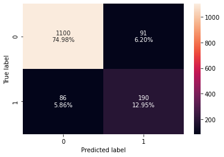

```python
#Fitting the model
d_tree = DecisionTreeClassifier(random_state=1)
d_tree.fit(X_train,y_train)

#Calculating different metrics
d_tree_model_train_perf=model_performance_classification_sklearn(d_tree,X_train,y_train)
print("Training performance:\n",d_tree_model_train_perf)
d_tree_model_test_perf=model_performance_classification_sklearn(d_tree,X_test,y_test)
print("Testing performance:\n",d_tree_model_test_perf)

#Creating confusion matrix
confusion_matrix_sklearn(d_tree,X_test,y_test)
```

##### Observation

- The results reveal that the decision tree model is overfitting the training data and yielding not such a good performance in terms of recall, precision and the balance of these two metrics, F1

### Hyperparameter Tuning

```python
#Choose the type of classifier.
dtree_estimator = DecisionTreeClassifier(class_weight={0:0.19,1:0.81},random_state=1)

# Grid of parameters to choose from
parameters = {'max_depth': np.arange(2,30),
              'min_samples_leaf': [1, 2, 5, 7, 10],
              'max_leaf_nodes' : [2, 3, 5, 10,15],
              'min_impurity_decrease': [0.0001,0.001,0.01,0.1]
             }

# Type of scoring used to compare parameter combinations
scorer = metrics.make_scorer(metrics.f1_score)

# Run the grid search
grid_obj = GridSearchCV(dtree_estimator, parameters, scoring=scorer,n_jobs=-1)
grid_obj = grid_obj.fit(X_train, y_train)

# Set the clf to the best combination of parameters
dtree_estimator = grid_obj.best_estimator_

# Fit the best algorithm to the data.
dtree_estimator.fit(X_train, y_train)
```

```
DecisionTreeClassifier(class_weight={0: 0.19, 1: 0.81}, max_depth=5,
                       max_leaf_nodes=15, min_impurity_decrease=0.0001,
                       random_state=1)
```

```
Training performance:
    Accuracy    Recall  Precision        F1
0  0.780181  0.670807   0.444444  0.534653
Testing performance:
    Accuracy    Recall  Precision        F1
0  0.786639  0.666667   0.454321  0.540382
```

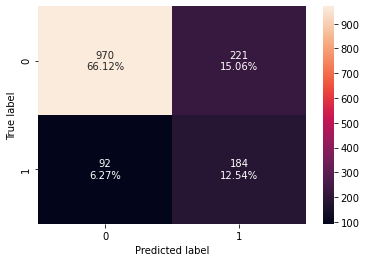

```python
#Calculating different metrics
dtree_estimator_model_train_perf=model_performance_classification_sklearn(dtree_estimator,X_train,y_train)
print("Training performance:\n",dtree_estimator_model_train_perf)
dtree_estimator_model_test_perf=model_performance_classification_sklearn(dtree_estimator,X_test,y_test)
print("Testing performance:\n",dtree_estimator_model_test_perf)

#Creating confusion matrix
confusion_matrix_sklearn(dtree_estimator,X_test,y_test)
```

##### Observation

- The good news for the tuned decision tree model is that it is no longer overfitting
- As we can see, however, it is making a lot of mistakes, misclassifying 21.33% of the target value predictions in the test dataset

## Random Forest Classifier

```
Training performance:
    Accuracy  Recall  Precision   F1
0       1.0     1.0        1.0  1.0
Testing performance:
    Accuracy    Recall  Precision        F1
0  0.911384  0.565217   0.939759  0.705882
```

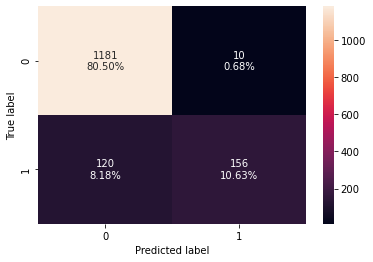

```python
#Fitting the model
rf_estimator = RandomForestClassifier(random_state=1)
rf_estimator.fit(X_train,y_train)

#Calculating different metrics
rf_estimator_model_train_perf=model_performance_classification_sklearn(rf_estimator,X_train,y_train)
print("Training performance:\n",rf_estimator_model_train_perf)
rf_estimator_model_test_perf=model_performance_classification_sklearn(rf_estimator,X_test,y_test)
print("Testing performance:\n",rf_estimator_model_test_perf)

#Creating confusion matrix
confusion_matrix_sklearn(rf_estimator,X_test,y_test)
```

##### Observation

- We see training model overfitting data
- Model produces high accuracy and precision scores but low recall

### Hyperparameter Tuning

```python
# Choose the type of classifier.
rf_tuned = RandomForestClassifier(class_weight={0:0.19,1:0.81},random_state=1,oob_score=True,bootstrap=True)

parameters = {
                'max_depth': list(np.arange(5,30,5)) + [None],
                'max_features': ['sqrt','log2',None],
                'min_samples_leaf': np.arange(1,15,5),
                'min_samples_split': np.arange(2, 20, 5),
                'n_estimators': np.arange(10,150,10)}


# Type of scoring used to compare parameter combinations
scorer = metrics.make_scorer(metrics.f1_score)

# Run the grid search
grid_obj = GridSearchCV(rf_tuned, parameters, scoring=scorer, cv=5,n_jobs=-1)
grid_obj = grid_obj.fit(X_train, y_train)

# Set the clf to the best combination of parameters
rf_tuned = grid_obj.best_estimator_

# Fit the best algorithm to the data.
rf_tuned.fit(X_train, y_train)
```

```
RandomForestClassifier(class_weight={0: 0.19, 1: 0.81}, max_depth=20,
                       max_features=None, min_samples_split=7, oob_score=True,
                       random_state=1)
```

```
Training performance:
    Accuracy    Recall  Precision        F1
0  0.995908  0.995342   0.983129  0.989198
Testing performance:
    Accuracy    Recall  Precision        F1
0  0.916837  0.677536       0.85  0.754032
```

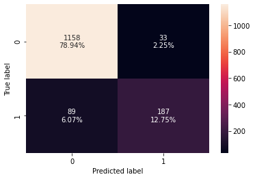

```python
#Calculating different metrics
rf_tuned_model_train_perf=model_performance_classification_sklearn(rf_tuned,X_train,y_train)
print("Training performance:\n",rf_tuned_model_train_perf)
rf_tuned_model_test_perf=model_performance_classification_sklearn(rf_tuned,X_test,y_test)
print("Testing performance:\n",rf_tuned_model_test_perf)

#Creating confusion matrix
confusion_matrix_sklearn(rf_tuned,X_test,y_test)
```

##### Observation

- The tuned model is still overfitting but less so than the original random forest model
- We observe a slight improvement in F1 score (i.e., balance between recall and precision performance), from 0.706 to 0.754

## Bagging Classifier

```
   Accuracy    Recall  Precision        F1
0  0.993861  0.968944     0.9984  0.983452
   Accuracy    Recall  Precision        F1
0  0.912065  0.634058   0.862069  0.730689
```

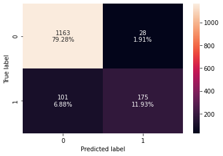

```python
#Fitting the model
bagging_classifier = BaggingClassifier(random_state=1)
bagging_classifier.fit(X_train,y_train)

#Calculating different metrics
bagging_classifier_model_train_perf=model_performance_classification_sklearn(bagging_classifier,X_train,y_train)
print(bagging_classifier_model_train_perf)
bagging_classifier_model_test_perf=model_performance_classification_sklearn(bagging_classifier,X_test,y_test)
print(bagging_classifier_model_test_perf)

#Creating confusion matrix
confusion_matrix_sklearn(bagging_classifier,X_test,y_test)
```

##### Observation

- Bagging model is overfitting training data though less so than decision tree model
- We observe higher performance in terms of precision but not so strong recall

### Hyperparameter Tuning

```python
# Choose the type of classifier.
bagging_estimator_tuned = BaggingClassifier(random_state=1)

# Grid of parameters to choose from
parameters = {'max_samples': [0.7,0.8,0.9,1],
              'max_features': [0.7,0.8,0.9,1],
              'n_estimators' : [10,20,30,40,50],
             }

# Type of scoring used to compare parameter combinations
scorer = metrics.make_scorer(metrics.f1_score)

# Run the grid search
grid_obj = GridSearchCV(bagging_estimator_tuned, parameters, scoring=scorer,cv=5)
grid_obj = grid_obj.fit(X_train, y_train)

# Set the clf to the best combination of parameters
bagging_estimator_tuned = grid_obj.best_estimator_

# Fit the best algorithm to the data.
bagging_estimator_tuned.fit(X_train, y_train)
```

```
BaggingClassifier(max_features=0.9, max_samples=0.9, n_estimators=40,
                  random_state=1)
```

```
   Accuracy    Recall  Precision        F1
0  0.999708  0.998447        1.0  0.999223
   Accuracy   Recall  Precision        F1
0  0.929107  0.65942   0.947917  0.777778
```

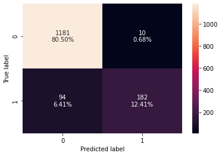

```python
#Calculating different metrics
bagging_estimator_tuned_model_train_perf=model_performance_classification_sklearn(bagging_estimator_tuned,X_train,y_train)
print(bagging_estimator_tuned_model_train_perf)
bagging_estimator_tuned_model_test_perf=model_performance_classification_sklearn(bagging_estimator_tuned,X_test,y_test)
print(bagging_estimator_tuned_model_test_perf)

#Creating confusion matrix
confusion_matrix_sklearn(bagging_estimator_tuned,X_test,y_test)
```

##### Observation

- After fine-tuning adjustments we still see model overfitting training data
- No real improvement in the performance on test data observed
- Although F1 score performance was attempted to be maximize we do not observe much improvement

## AdaBoost Classifier

```
   Accuracy    Recall  Precision        F1
0  0.847413  0.313665   0.716312  0.436285
   Accuracy    Recall  Precision        F1
0  0.847307  0.311594   0.716667  0.434343
```

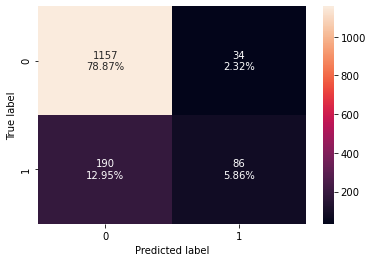

```python
#Fitting the model
ab_classifier = AdaBoostClassifier(random_state=1)
ab_classifier.fit(X_train,y_train)

#Calculating different metrics
ab_classifier_model_train_perf=model_performance_classification_sklearn(ab_classifier,X_train,y_train)
print(ab_classifier_model_train_perf)
ab_classifier_model_test_perf=model_performance_classification_sklearn(ab_classifier,X_test,y_test)
print(ab_classifier_model_test_perf)

#Creating confusion matrix
confusion_matrix_sklearn(ab_classifier,X_test,y_test)
```

##### Observation

- The good news we observe here is that the model is not overfitting the data
- The not-so-good news is that it is not performing well, especially in terms of recall

### Hyperparameter Tuning

```python
# Choose the type of classifier.
abc_tuned = AdaBoostClassifier(random_state=1)

# Grid of parameters to choose from
parameters = {
    #Let's try different max_depth for base_estimator
    "base_estimator":[DecisionTreeClassifier(max_depth=1),DecisionTreeClassifier(max_depth=2),
                      DecisionTreeClassifier(max_depth=3)],
    "n_estimators": np.arange(10,110,10),
    "learning_rate":np.arange(0.1,2,0.1)
}

# Type of scoring used to compare parameter  combinations
scorer = metrics.make_scorer(metrics.f1_score)

# Run the grid search
grid_obj = GridSearchCV(abc_tuned, parameters, scoring=scorer,cv=5)
grid_obj = grid_obj.fit(X_train, y_train)

# Set the clf to the best combination of parameters
abc_tuned = grid_obj.best_estimator_

# Fit the best algorithm to the data.
abc_tuned.fit(X_train, y_train)
```

```
AdaBoostClassifier(base_estimator=DecisionTreeClassifier(max_depth=3),
                   learning_rate=0.9, n_estimators=90, random_state=1)
```

```
   Accuracy    Recall  Precision       F1
0  0.977784  0.903727    0.97651  0.93871
   Accuracy    Recall  Precision        F1
0  0.875937  0.568841   0.713636  0.633065
```

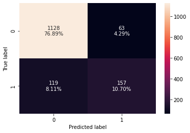

```python
#Calculating different metrics
abc_tuned_model_train_perf=model_performance_classification_sklearn(abc_tuned,X_train,y_train)
print(abc_tuned_model_train_perf)
abc_tuned_model_test_perf=model_performance_classification_sklearn(abc_tuned,X_test,y_test)
print(abc_tuned_model_test_perf)

#Creating confusion matrix
confusion_matrix_sklearn(abc_tuned,X_test,y_test)
```

##### Observation

- Unfortunately, the tuned model started to overfit data
- We observe improved though still underperforming F1 score due to low recall performance

## Gradient Boosting Classifier

```
Training performance:
    Accuracy    Recall  Precision        F1
0   0.88249  0.445652   0.864458  0.588115
Testing performance:
    Accuracy    Recall  Precision        F1
0  0.865031  0.380435   0.795455  0.514706
```

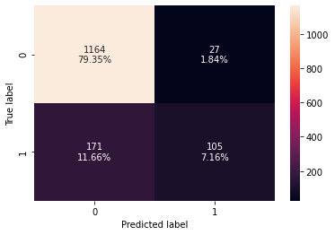

```python
#Fitting the model
gb_classifier = GradientBoostingClassifier(random_state=1)
gb_classifier.fit(X_train,y_train)

#Calculating different metrics
gb_classifier_model_train_perf=model_performance_classification_sklearn(gb_classifier,X_train,y_train)
print("Training performance:\n",gb_classifier_model_train_perf)
gb_classifier_model_test_perf=model_performance_classification_sklearn(gb_classifier,X_test,y_test)
print("Testing performance:\n",gb_classifier_model_test_perf)

#Creating confusion matrix
confusion_matrix_sklearn(gb_classifier,X_test,y_test)
```

##### Observation

- Though not overfitting the data, the model is performing poorly in terms of recall (meaning presence of a high number of false negative predictions) and thereby F1 score

### Hyperparameter Tuning

```python
# Choose the type of classifier.
gbc_tuned = GradientBoostingClassifier(init=AdaBoostClassifier(random_state=1),random_state=1)

# Grid of parameters to choose from
parameters = {
    "n_estimators": [100,150,200,250],
    "subsample":[0.8,0.9,1],
    "max_features":[0.7,0.8,0.9,1]
}

# Type of scoring used to compare parameter combinations
scorer = metrics.make_scorer(metrics.f1_score)

# Run the grid search
grid_obj = GridSearchCV(gbc_tuned, parameters, scoring=scorer,cv=5)
grid_obj = grid_obj.fit(X_train, y_train)

# Set the clf to the best combination of parameters
gbc_tuned = grid_obj.best_estimator_

# Fit the best algorithm to the data.
gbc_tuned.fit(X_train, y_train)
```

```
GradientBoostingClassifier(init=AdaBoostClassifier(random_state=1),
                           max_features=0.9, n_estimators=250, random_state=1,
                           subsample=0.9)
```

```
Training performance:
    Accuracy   Recall  Precision        F1
0  0.918445  0.60559   0.939759  0.736544
Testing performance:
    Accuracy    Recall  Precision        F1
0  0.881391  0.485507   0.807229  0.606335
```

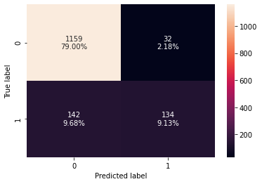

```python
#Calculating different metrics
gbc_tuned_model_train_perf=model_performance_classification_sklearn(gbc_tuned,X_train,y_train)
print("Training performance:\n",gbc_tuned_model_train_perf)
gbc_tuned_model_test_perf=model_performance_classification_sklearn(gbc_tuned,X_test,y_test)
print("Testing performance:\n",gbc_tuned_model_test_perf)

#Creating confusion matrix
confusion_matrix_sklearn(gbc_tuned,X_test,y_test)
```

##### Observation

- Tuned model improved slightly in terms of F1 performance but began to overfit
- Type II error: model misclassifying a lot of actual buyers as non-buyers (nearly 10%)

## XGBoost Classifier

```
Training performance:
    Accuracy    Recall  Precision        F1
0  0.999708  0.998447        1.0  0.999223
Testing performance:
    Accuracy    Recall  Precision        F1
0   0.93047  0.706522   0.902778  0.792683
```

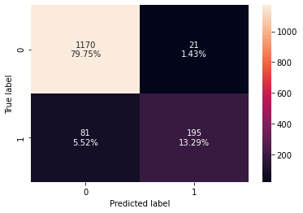

```python
#Fitting the model
xgb_classifier = XGBClassifier(random_state=1, eval_metric='logloss')
xgb_classifier.fit(X_train,y_train)

#Calculating different metrics
xgb_classifier_model_train_perf=model_performance_classification_sklearn(xgb_classifier,X_train,y_train)
print("Training performance:\n",xgb_classifier_model_train_perf)
xgb_classifier_model_test_perf=model_performance_classification_sklearn(xgb_classifier,X_test,y_test)
print("Testing performance:\n",xgb_classifier_model_test_perf)

#Creating confusion matrix
confusion_matrix_sklearn(xgb_classifier,X_test,y_test)
```

##### Observation

- Model is overfitting data as we observe especially large discrepancy between training and test scores for recall and F1

### Hyperparameter Tuning

```python
# Choose the type of classifier.
xgb_tuned = XGBClassifier(random_state=1, eval_metric='logloss')

# Grid of parameters to choose from
parameters = {
    "n_estimators": [30,50,75],
    "scale_pos_weight":[1,2,5],
    "subsample":[0.7,0.9,1],
    "gamma":[0, 1, 3, 5],
    "learning_rate":[0.05, 0.1,0.2],
    "colsample_bytree":[0.7,0.9,1],
    "colsample_bylevel":[0.5,0.7,1]
}

# Type of scoring used to compare parameter combinations
scorer = metrics.make_scorer(metrics.f1_score)

# Run the grid search
grid_obj = GridSearchCV(xgb_tuned, parameters,scoring=scorer,cv=5)
grid_obj = grid_obj.fit(X_train, y_train)

# Set the clf to the best combination of parameters
xgb_tuned = grid_obj.best_estimator_

# Fit the best algorithm to the data.
xgb_tuned.fit(X_train, y_train)
```

```
XGBClassifier(base_score=0.5, booster='gbtree', colsample_bylevel=0.7,
              colsample_bynode=1, colsample_bytree=1, eval_metric='logloss',
              gamma=0, gpu_id=-1, importance_type='gain',
              interaction_constraints='', learning_rate=0.2, max_delta_step=0,
              max_depth=6, min_child_weight=1, missing=nan,
              monotone_constraints='()', n_estimators=75, n_jobs=4,
              num_parallel_tree=1, random_state=1, reg_alpha=0, reg_lambda=1,
              scale_pos_weight=5, subsample=1, tree_method='exact',
              validate_parameters=1, verbosity=None)
```

```
Training performance:
    Accuracy    Recall  Precision        F1
0  0.992692  0.998447   0.964018  0.980931
Testing performance:
    Accuracy    Recall  Precision        F1
0  0.923654  0.836957   0.775168  0.804878
```

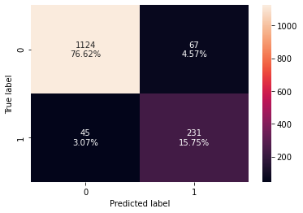

```python
#Calculating different metrics
xgb_tuned_model_train_perf=model_performance_classification_sklearn(xgb_tuned,X_train,y_train)
print("Training performance:\n",xgb_tuned_model_train_perf)
xgb_tuned_model_test_perf=model_performance_classification_sklearn(xgb_tuned,X_test,y_test)
print("Testing performance:\n",xgb_tuned_model_test_perf)

#Creating confusion matrix
confusion_matrix_sklearn(xgb_tuned,X_test,y_test)
```

#### Observation

- We see XGBoost tuned model overfitting less than the original and with improved performance, yielding the highest F1 performance score of all our models: 0.805

## Stacking Classifier

```python
estimators = [('Random Forest Tuned',rf_tuned), ('Decision Tree Estimator',dtree_estimator), ('AdaBoost Classifier Tuned',abc_tuned)]

final_estimator = xgb_tuned

stacking_classifier= StackingClassifier(estimators=estimators,final_estimator=final_estimator)

stacking_classifier.fit(X_train,y_train)
```

```
StackingClassifier(estimators=[('Random Forest Tuned',
                                RandomForestClassifier(class_weight={0: 0.19,
                                                                     1: 0.81},
                                                       max_depth=20,
                                                       max_features=None,
                                                       min_samples_split=7,
                                                       oob_score=True,
                                                       random_state=1)),
                               ('Decision Tree Estimator',
                                DecisionTreeClassifier(class_weight={0: 0.19,
                                                                     1: 0.81},
                                                       max_depth=5,
                                                       max_leaf_nodes=15,
                                                       min_impurity_decrease=0.0001,
                                                       random_state=1)),
                               ('AdaBoost...
                                                 eval_metric='logloss', gamma=0,
                                                 gpu_id=-1,
                                                 importance_type='gain',
                                                 interaction_constraints='',
                                                 learning_rate=0.2,
                                                 max_delta_step=0, max_depth=6,
                                                 min_child_weight=1,
                                                 missing=nan,
                                                 monotone_constraints='()',
                                                 n_estimators=75, n_jobs=4,
                                                 num_parallel_tree=1,
                                                 random_state=1, reg_alpha=0,
                                                 reg_lambda=1,
                                                 scale_pos_weight=5,
                                                 subsample=1,
                                                 tree_method='exact',
                                                 validate_parameters=1,
                                                 verbosity=None))
```

```
Training performance:
    Accuracy  Recall  Precision        F1
0  0.985677     1.0   0.929293  0.963351
Testing performance:
    Accuracy   Recall  Precision        F1
0  0.903204  0.82971    0.70679  0.763333
```

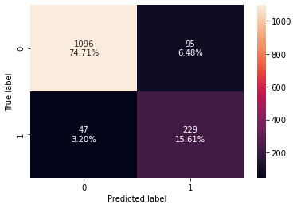

```python
#Calculating different metrics
stacking_classifier_model_train_perf=model_performance_classification_sklearn(stacking_classifier,X_train,y_train)
print("Training performance:\n",stacking_classifier_model_train_perf)
stacking_classifier_model_test_perf=model_performance_classification_sklearn(stacking_classifier,X_test,y_test)
print("Testing performance:\n",stacking_classifier_model_test_perf)

#Creating confusion matrix
confusion_matrix_sklearn(stacking_classifier,X_test,y_test)
```

##### Observation

- Although overall model is delivering pretty good performance scores it is unfortunately overfitting training data

## Comparing all models

```python
# training performance comparison

models_train_comp_df = pd.concat(
    [d_tree_model_train_perf.T,dtree_estimator_model_train_perf.T,rf_estimator_model_train_perf.T,rf_tuned_model_train_perf.T,
     bagging_classifier_model_train_perf.T,bagging_estimator_tuned_model_train_perf.T,ab_classifier_model_train_perf.T,
     abc_tuned_model_train_perf.T,gb_classifier_model_train_perf.T,gbc_tuned_model_train_perf.T,xgb_classifier_model_train_perf.T,
    xgb_tuned_model_train_perf.T,stacking_classifier_model_train_perf.T],
    axis=1,
)
models_train_comp_df.columns = [
    "Decision Tree",
    "Decision Tree Estimator",
    "Random Forest Estimator",
    "Random Forest Tuned",
    "Bagging Classifier",
    "Bagging Estimator Tuned",
    "Adaboost Classifier",
    "Adabosst Classifier Tuned",
    "Gradient Boost Classifier",
    "Gradient Boost Classifier Tuned",
    "XGBoost Classifier",
    "XGBoost Classifier Tuned",
    "Stacking Classifier"]
print("Training performance comparison:")
models_train_comp_df
```

```
Training performance comparison:
```

|  | Decision Tree | Decision Tree Estimator | Random Forest Estimator | Random Forest Tuned | Bagging Classifier | Bagging Estimator Tuned | Adaboost Classifier | Adabosst Classifier Tuned | Gradient Boost Classifier | Gradient Boost Classifier Tuned | XGBoost Classifier | XGBoost Classifier Tuned | Stacking Classifier |
| --- | --- | --- | --- | --- | --- | --- | --- | --- | --- | --- | --- | --- | --- |
| Accuracy | 1.0 | 0.780181 | 1.0 | 0.995908 | 0.993861 | 0.999708 | 0.847413 | 0.977784 | 0.882490 | 0.918445 | 0.999708 | 0.992692 | 0.985677 |
| Recall | 1.0 | 0.670807 | 1.0 | 0.995342 | 0.968944 | 0.998447 | 0.313665 | 0.903727 | 0.445652 | 0.605590 | 0.998447 | 0.998447 | 1.000000 |
| Precision | 1.0 | 0.444444 | 1.0 | 0.983129 | 0.998400 | 1.000000 | 0.716312 | 0.976510 | 0.864458 | 0.939759 | 1.000000 | 0.964018 | 0.929293 |
| F1 | 1.0 | 0.534653 | 1.0 | 0.989198 | 0.983452 | 0.999223 | 0.436285 | 0.938710 | 0.588115 | 0.736544 | 0.999223 | 0.980931 | 0.963351 |

```python
# testing performance comparison

models_test_comp_df = pd.concat(
    [d_tree_model_test_perf.T,dtree_estimator_model_test_perf.T,rf_estimator_model_test_perf.T,rf_tuned_model_test_perf.T,
     bagging_classifier_model_test_perf.T,bagging_estimator_tuned_model_test_perf.T,ab_classifier_model_test_perf.T,
     abc_tuned_model_test_perf.T,gb_classifier_model_test_perf.T,gbc_tuned_model_test_perf.T,xgb_classifier_model_test_perf.T,
    xgb_tuned_model_test_perf.T,stacking_classifier_model_test_perf.T],
    axis=1,
)
models_test_comp_df.columns = [
    "Decision Tree",
    "Decision Tree Estimator",
    "Random Forest Estimator",
    "Random Forest Tuned",
    "Bagging Classifier",
    "Bagging Estimator Tuned",
    "Adaboost Classifier",
    "Adabosst Classifier Tuned",
    "Gradient Boost Classifier",
    "Gradient Boost Classifier Tuned",
    "XGBoost Classifier",
    "XGBoost Classifier Tuned",
    "Stacking Classifier"]
print("Testing performance comparison:")
models_test_comp_df
```

```
Testing performance comparison:
```

|  | Decision Tree | Decision Tree Estimator | Random Forest Estimator | Random Forest Tuned | Bagging Classifier | Bagging Estimator Tuned | Adaboost Classifier | Adabosst Classifier Tuned | Gradient Boost Classifier | Gradient Boost Classifier Tuned | XGBoost Classifier | XGBoost Classifier Tuned | Stacking Classifier |
| --- | --- | --- | --- | --- | --- | --- | --- | --- | --- | --- | --- | --- | --- |
| Accuracy | 0.879346 | 0.786639 | 0.911384 | 0.916837 | 0.912065 | 0.929107 | 0.847307 | 0.875937 | 0.865031 | 0.881391 | 0.930470 | 0.923654 | 0.903204 |
| Recall | 0.688406 | 0.666667 | 0.565217 | 0.677536 | 0.634058 | 0.659420 | 0.311594 | 0.568841 | 0.380435 | 0.485507 | 0.706522 | 0.836957 | 0.829710 |
| Precision | 0.676157 | 0.454321 | 0.939759 | 0.850000 | 0.862069 | 0.947917 | 0.716667 | 0.713636 | 0.795455 | 0.807229 | 0.902778 | 0.775168 | 0.706790 |
| F1 | 0.682226 | 0.540382 | 0.705882 | 0.754032 | 0.730689 | 0.777778 | 0.434343 | 0.633065 | 0.514706 | 0.606335 | 0.792683 | 0.804878 | 0.763333 |

#### Observation

- The majority of the models are overfitting the training data in terms of f1-score.
- When comparing performance scores across all of the models tested, we conclude that the tuned XGBoost model was our highest performer
- Though we still observe overfitting, tuned XGBoost is yielding a good, balanced performance in all measures and the highest F1 score of all models tested

### Feature importance of Tuned XGBoost

```python
# importance of features in the tree building ( The importance of a feature is computed as the
#(normalized) total reduction of the criterion brought by that feature. It is also known as the Gini importance )

print(pd.DataFrame(xgb_tuned.feature_importances_, columns = ["Imp"], index = X_train.columns).sort_values(by = 'Imp', ascending = False))
```

```
                                 Imp
Passport                    0.111989
Designation                 0.102095
CityTier                    0.075133
ProductPitched              0.071021
MaritalStatus_Married       0.065377
MaritalStatus_Single        0.062199
MaritalStatus_Unmarried     0.051513
PreferredPropertyStar       0.045900
Age                         0.041351
NumberOfFollowups           0.040952
PitchSatisfactionScore      0.037678
NumberOfTrips               0.036490
DurationOfPitch             0.036205
Occupation_Small Business   0.034325
TypeofContact_Self Enquiry  0.033584
MonthlyIncome               0.032271
Gender_Male                 0.028917
OwnCar                      0.025586
Occupation_Salaried         0.024795
NumberOfPersonVisiting      0.023918
NumberOfChildrenVisiting    0.018702
```

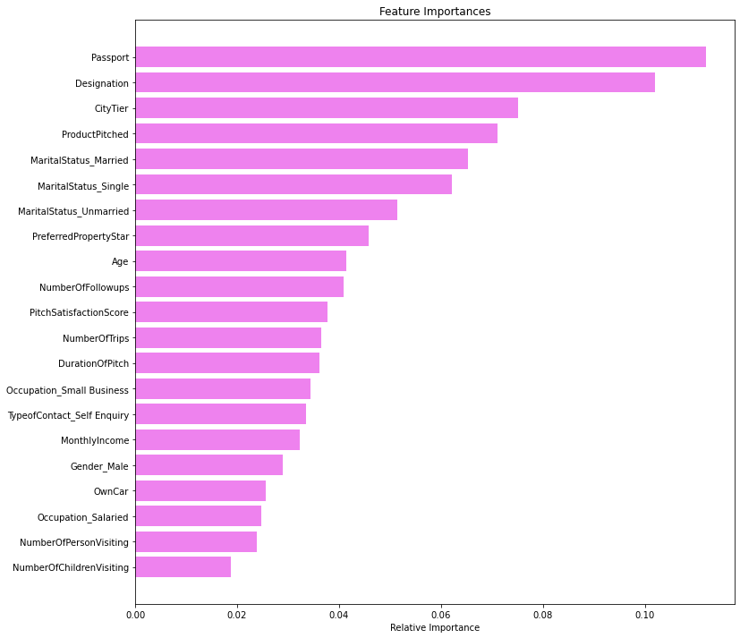

```python
feature_names = X_train.columns
importances = xgb_tuned.feature_importances_
indices = np.argsort(importances)

plt.figure(figsize=(12,12))
plt.title('Feature Importances')
plt.barh(range(len(indices)), importances[indices], color='violet', align='center')
plt.yticks(range(len(indices)), [feature_names[i] for i in indices])
plt.xlabel('Relative Importance')
plt.show()
```

##### Observation

- The graph above shows us a break down of feature importance for the tuned XGBoost model
- We see that the top 5 most important predictive features for the model are:
1. Whether customer owns a passport
2. Job designation (rank) of customer
3. City tier level in which customer resides
4. Travel package pitched to customer
5. Marital Status
- The model indicates that such features should be weighted more heavily by the marketing team as it devises a campaign to launch the new Wellness travel package

## Business Insights and Recommendations

###### Insights

- Based on the best predictive model, owning a passport (or not owning a passport) is a crucial component of whether a customer will purchase a travel package and what package they will be inclined to purchase
- Job rank (which is also a proxy for age and income) is also an important factor in terms of what travel package customers would be more likely to purchase: for example, younger, lower-ranked professionals are more likely to buy the Basic Package, whereas older higher-ranked professionals incline towards Standard and Deluxe Packages
- Another important and less obvious factor revealed by the model suggests the importance of level of development, population, facilities, and living standards of the city in which a customer resides
- The type of travel package pitched to customer also plays an important role, suggesting that a well-targeted marketing effort is crucial
- Marital status also plays a factor in determining travel package purchase decisions

###### Recommendations

Overall, the model gives us clues as to what factors should be prioritized in marketing the new Wellness package. Based on the insights, we suggest a customer segmentation strategy that takes into account:

- Whether or not a customer owns a passport - customers who do being generally more inclined to purchase a travel package
- The professional rank of the customer - an idea would be to develop different kinds of Wellness packages catering to the needs of customers at different points in their career development
- The characteristics of the customer’s city of residence which can give the marketing team important clues as to the needs of the customer - what kind of experiences a customer would likely seek given what their city of residence currently has (or does not have) to offer
- The package that is pitched to ensure that it is carefully tailored and promoted to the right customer
- The marital status of the customer. Again, this speaks to the importance of understanding key aspects of the life of the customer (both in personal and professional realms) and of developing a marketing strategy that caters to and is shaped by these characteristics